# cctv,범죄율시각화

```python
import numpy as np
import pandas as pd
```

## 범죄율 자료 만들기

```python
#서울시 5대범죄 자료 불러오기
df = pd.read_csv('서울5대범죄(2015~2018).csv')
df
```

|  | 기간 | 자치구 | 발생합계 | 검거합계 | 살인발생 | 살인검거 | 강도발생 | 강도검거 | 강간강제추행발생 | 강간강제추행검거 | 절도발생 | 절도검거 | 폭력발생 | 폭력검거 |
| --- | --- | --- | --- | --- | --- | --- | --- | --- | --- | --- | --- | --- | --- | --- |
| 0 | 2015 | 합계 | 126401 | 82680 | 163 | 156 | 276 | 257 | 5449 | 5069 | 55307 | 21842 | 65206 | 55356 |
| 1 | 2015 | 종로구 | 4705 | 4430 | 6 | 8 | 11 | 13 | 211 | 1139 | 2184 | 1145 | 2293 | 2125 |
| 2 | 2015 | 중구 | 4954 | 2942 | 3 | 2 | 9 | 6 | 170 | 111 | 2548 | 859 | 2224 | 1964 |
| 3 | 2015 | 용산구 | 3820 | 2483 | 5 | 5 | 14 | 14 | 194 | 173 | 1557 | 587 | 2050 | 1704 |
| 4 | 2015 | 성동구 | 3358 | 2123 | 4 | 4 | 9 | 8 | 126 | 119 | 1607 | 597 | 1612 | 1395 |
| ... | ... | ... | ... | ... | ... | ... | ... | ... | ... | ... | ... | ... | ... | ... |
| 99 | 2018 | 관악구 | 5026 | 3653 | 9 | 9 | 10 | 12 | 352 | 305 | 2012 | 1025 | 2643 | 2302 |
| 100 | 2018 | 서초구 | 4726 | 3183 | 5 | 5 | 5 | 5 | 470 | 315 | 1851 | 838 | 2395 | 2020 |
| 101 | 2018 | 강남구 | 7513 | 5196 | 10 | 13 | 14 | 10 | 600 | 523 | 3004 | 1317 | 3885 | 3333 |
| 102 | 2018 | 송파구 | 5807 | 4051 | 5 | 6 | 6 | 8 | 309 | 254 | 2352 | 1034 | 3135 | 2749 |
| 103 | 2018 | 강동구 | 3919 | 2789 | 3 | 3 | 7 | 7 | 170 | 143 | 1515 | 765 | 2224 | 1871 |

104 rows × 14 columns

```python
df['전체검거율']=df['검거합계']/df['발생합계']*100
df['살인검거율']=df['살인검거']/df['살인발생']*100
df['강도검거율']=df['강도검거']/df['강도발생']*100
df['강간강제추행검거율']=df['강간강제추행검거']/df['강간강제추행발생']*100
df['절도검거율']=df['절도검거']/df['절도발생']*100
df['폭력검거율']=df['폭력검거']/df['폭력발생']*100
```

```python
df.head()
```

|  | 기간 | 자치구 | 발생합계 | 검거합계 | 살인발생 | 살인검거 | 강도발생 | 강도검거 | 강간강제추행발생 | 강간강제추행검거 | 절도발생 | 절도검거 | 폭력발생 | 폭력검거 | 전체검거율 | 살인검거율 | 강도검거율 | 강간강제추행검거율 | 절도검거율 | 폭력검거율 |
| --- | --- | --- | --- | --- | --- | --- | --- | --- | --- | --- | --- | --- | --- | --- | --- | --- | --- | --- | --- | --- |
| 0 | 2015 | 합계 | 126401 | 82680 | 163 | 156 | 276 | 257 | 5449 | 5069 | 55307 | 21842 | 65206 | 55356 | 65.410875 | 95.705521 | 93.115942 | 93.026243 | 39.492288 | 84.894028 |
| 1 | 2015 | 종로구 | 4705 | 4430 | 6 | 8 | 11 | 13 | 211 | 1139 | 2184 | 1145 | 2293 | 2125 | 94.155154 | 133.333333 | 118.181818 | 539.810427 | 52.426740 | 92.673354 |
| 2 | 2015 | 중구 | 4954 | 2942 | 3 | 2 | 9 | 6 | 170 | 111 | 2548 | 859 | 2224 | 1964 | 59.386354 | 66.666667 | 66.666667 | 65.294118 | 33.712716 | 88.309353 |
| 3 | 2015 | 용산구 | 3820 | 2483 | 5 | 5 | 14 | 14 | 194 | 173 | 1557 | 587 | 2050 | 1704 | 65.000000 | 100.000000 | 100.000000 | 89.175258 | 37.700706 | 83.121951 |
| 4 | 2015 | 성동구 | 3358 | 2123 | 4 | 4 | 9 | 8 | 126 | 119 | 1607 | 597 | 1612 | 1395 | 63.222156 | 100.000000 | 88.888889 | 94.444444 | 37.149969 | 86.538462 |

```python
crime = df
```

```python
crime.head(3)
```

|  | 기간 | 자치구 | 발생합계 | 검거합계 | 살인발생 | 살인검거 | 강도발생 | 강도검거 | 강간강제추행발생 | 강간강제추행검거 | 절도발생 | 절도검거 | 폭력발생 | 폭력검거 | 전체검거율 | 살인검거율 | 강도검거율 | 강간강제추행검거율 | 절도검거율 | 폭력검거율 |
| --- | --- | --- | --- | --- | --- | --- | --- | --- | --- | --- | --- | --- | --- | --- | --- | --- | --- | --- | --- | --- |
| 0 | 2015 | 합계 | 126401 | 82680 | 163 | 156 | 276 | 257 | 5449 | 5069 | 55307 | 21842 | 65206 | 55356 | 65.410875 | 95.705521 | 93.115942 | 93.026243 | 39.492288 | 84.894028 |
| 1 | 2015 | 종로구 | 4705 | 4430 | 6 | 8 | 11 | 13 | 211 | 1139 | 2184 | 1145 | 2293 | 2125 | 94.155154 | 133.333333 | 118.181818 | 539.810427 | 52.426740 | 92.673354 |
| 2 | 2015 | 중구 | 4954 | 2942 | 3 | 2 | 9 | 6 | 170 | 111 | 2548 | 859 | 2224 | 1964 | 59.386354 | 66.666667 | 66.666667 | 65.294118 | 33.712716 | 88.309353 |

```python
a = ['전체검거율','살인검거율','강도검거율',
     '강간강제추행검거율','절도검거율','폭력검거율']
for i in a:
    crime.loc[crime[i]>100,i]=100
crime.head()
```

|  | 기간 | 자치구 | 발생합계 | 검거합계 | 살인발생 | 살인검거 | 강도발생 | 강도검거 | 강간강제추행발생 | 강간강제추행검거 | 절도발생 | 절도검거 | 폭력발생 | 폭력검거 | 전체검거율 | 살인검거율 | 강도검거율 | 강간강제추행검거율 | 절도검거율 | 폭력검거율 |
| --- | --- | --- | --- | --- | --- | --- | --- | --- | --- | --- | --- | --- | --- | --- | --- | --- | --- | --- | --- | --- |
| 0 | 2015 | 합계 | 126401 | 82680 | 163 | 156 | 276 | 257 | 5449 | 5069 | 55307 | 21842 | 65206 | 55356 | 65.410875 | 95.705521 | 93.115942 | 93.026243 | 39.492288 | 84.894028 |
| 1 | 2015 | 종로구 | 4705 | 4430 | 6 | 8 | 11 | 13 | 211 | 1139 | 2184 | 1145 | 2293 | 2125 | 94.155154 | 100.000000 | 100.000000 | 100.000000 | 52.426740 | 92.673354 |
| 2 | 2015 | 중구 | 4954 | 2942 | 3 | 2 | 9 | 6 | 170 | 111 | 2548 | 859 | 2224 | 1964 | 59.386354 | 66.666667 | 66.666667 | 65.294118 | 33.712716 | 88.309353 |
| 3 | 2015 | 용산구 | 3820 | 2483 | 5 | 5 | 14 | 14 | 194 | 173 | 1557 | 587 | 2050 | 1704 | 65.000000 | 100.000000 | 100.000000 | 89.175258 | 37.700706 | 83.121951 |
| 4 | 2015 | 성동구 | 3358 | 2123 | 4 | 4 | 9 | 8 | 126 | 119 | 1607 | 597 | 1612 | 1395 | 63.222156 | 100.000000 | 88.888889 | 94.444444 | 37.149969 | 86.538462 |

## 면적 데이터 불러오기

```python
area = pd.read_csv('서울시면적.csv')
area.head(3)
```

|  | 기간 | 자치구 | 면적 | 구성비(%) | 행정 | 법정 | 통 | 반 |
| --- | --- | --- | --- | --- | --- | --- | --- | --- |
| 0 | 2015 | 종로구 | 23.91 | 3.95 | 17 | 87 | 269 | 1529 |
| 1 | 2015 | 중구 | 9.96 | 1.65 | 15 | 74 | 254 | 1599 |
| 2 | 2015 | 용산구 | 21.87 | 3.61 | 16 | 36 | 351 | 2563 |

```python
area = pd.read_csv('서울시면적.csv',usecols=['기간','자치구','면적'])
area.head(3)
```

|  | 기간 | 자치구 | 면적 |
| --- | --- | --- | --- |
| 0 | 2015 | 종로구 | 23.91 |
| 1 | 2015 | 중구 | 9.96 |
| 2 | 2015 | 용산구 | 21.87 |

## 인구수 자료 만들기

```python
#서울시 인구통계 자료 불러오기
pop = pd.read_csv('인구수(2015~2018).csv',header=2)
pop.head()
```

|  | 기간 | 자치구 | 세대 | 계 | 남자 | 여자 | 계.1 | 남자.1 | 여자.1 | 계.2 | 남자.2 | 여자.2 | 세대당인구 | 65세이상고령자 |
| --- | --- | --- | --- | --- | --- | --- | --- | --- | --- | --- | --- | --- | --- | --- |
| 0 | 2015 | 합계 | 4189948 | 10297138 | 5063550 | 5233588 | 10022181 | 4930943 | 5091238 | 274957 | 132607 | 142350 | 2.39 | 1267563 |
| 1 | 2015 | 종로구 | 72645 | 163822 | 80531 | 83291 | 154986 | 76548 | 78438 | 8836 | 3983 | 4853 | 2.13 | 24892 |
| 2 | 2015 | 중구 | 59321 | 134329 | 66755 | 67574 | 125733 | 62687 | 63046 | 8596 | 4068 | 4528 | 2.12 | 20302 |
| 3 | 2015 | 용산구 | 107512 | 247909 | 121027 | 126882 | 233342 | 113177 | 120165 | 14567 | 7850 | 6717 | 2.17 | 35715 |
| 4 | 2015 | 성동구 | 126714 | 305065 | 151459 | 153606 | 297003 | 147570 | 149433 | 8062 | 3889 | 4173 | 2.34 | 38164 |

```python
pop = pd.read_csv('인구수(2015~2018).csv',
                 header=2,
                 usecols=['기간','자치구','계','계.1','계.2','65세이상고령자'])
pop.head()
```

|  | 기간 | 자치구 | 계 | 계.1 | 계.2 | 65세이상고령자 |
| --- | --- | --- | --- | --- | --- | --- |
| 0 | 2015 | 합계 | 10297138 | 10022181 | 274957 | 1267563 |
| 1 | 2015 | 종로구 | 163822 | 154986 | 8836 | 24892 |
| 2 | 2015 | 중구 | 134329 | 125733 | 8596 | 20302 |
| 3 | 2015 | 용산구 | 247909 | 233342 | 14567 | 35715 |
| 4 | 2015 | 성동구 | 305065 | 297003 | 8062 | 38164 |

```python
pop.columns=['기간','자치구','인구수','내국인','외국인','고령자']
pop.head()
```

|  | 기간 | 자치구 | 인구수 | 내국인 | 외국인 | 고령자 |
| --- | --- | --- | --- | --- | --- | --- |
| 0 | 2015 | 합계 | 10297138 | 10022181 | 274957 | 1267563 |
| 1 | 2015 | 종로구 | 163822 | 154986 | 8836 | 24892 |
| 2 | 2015 | 중구 | 134329 | 125733 | 8596 | 20302 |
| 3 | 2015 | 용산구 | 247909 | 233342 | 14567 | 35715 |
| 4 | 2015 | 성동구 | 305065 | 297003 | 8062 | 38164 |

## CCTV데이터 불러오기

```python
cctv= pd.read_csv('final.csv',
                 usecols=['기간','자치구','cctv설치수'])
cctv.head()
```

|  | 기간 | 자치구 | cctv설치수 |
| --- | --- | --- | --- |
| 0 | 2015 | 종로구 | 195.0 |
| 1 | 2015 | 중구 | 245.0 |
| 2 | 2015 | 용산구 | 102.0 |
| 3 | 2015 | 성동구 | 258.0 |
| 4 | 2015 | 광진구 | 64.0 |

```python
cctvplus=pd.read_excel('cctv소계.xlsx')
cctvplus.columns=['기간','자치구','cctv총합']
cctvplus.head()
```

|  | 기간 | 자치구 | cctv총합 |
| --- | --- | --- | --- |
| 0 | 2015 | 강남구 | 3431 |
| 1 | 2015 | 강동구 | 1027 |
| 2 | 2015 | 강북구 | 691 |
| 3 | 2015 | 강서구 | 909 |
| 4 | 2015 | 관악구 | 2001 |

```python
cctv=pd.merge(cctv,cctvplus, on=['기간','자치구'])
```

```python
cctv.head()
```

|  | 기간 | 자치구 | cctv설치수 | cctv총합 |
| --- | --- | --- | --- | --- |
| 0 | 2015 | 종로구 | 195.0 | 941 |
| 1 | 2015 | 중구 | 245.0 | 629 |
| 2 | 2015 | 용산구 | 102.0 | 1841 |
| 3 | 2015 | 성동구 | 258.0 | 1251 |
| 4 | 2015 | 광진구 | 64.0 | 746 |

### 네 데이터 합치기

- 5대범죄 검거율
- 인구수
- cctv설치 수
- 서울시 면적

```python
dataseoul = pd.merge(area,pop,on=['기간','자치구'])
dataseoul.head(3)
```

|  | 기간 | 자치구 | 면적 | 인구수 | 내국인 | 외국인 | 고령자 |
| --- | --- | --- | --- | --- | --- | --- | --- |
| 0 | 2015 | 종로구 | 23.91 | 163822 | 154986 | 8836 | 24892 |
| 1 | 2015 | 중구 | 9.96 | 134329 | 125733 | 8596 | 20302 |
| 2 | 2015 | 용산구 | 21.87 | 247909 | 233342 | 14567 | 35715 |

```python
dataseoul=pd.merge(dataseoul,crime, on=['기간','자치구'])
```

```python
dataseoul=pd.merge(dataseoul,cctv,on=['기간','자치구'])
dataseoul.head()
```

|  | 기간 | 자치구 | 면적 | 인구수 | 내국인 | 외국인 | 고령자 | 발생합계 | 검거합계 | 살인발생 | ... | 폭력발생 | 폭력검거 | 전체검거율 | 살인검거율 | 강도검거율 | 강간강제추행검거율 | 절도검거율 | 폭력검거율 | cctv설치수 | cctv총합 |
| --- | --- | --- | --- | --- | --- | --- | --- | --- | --- | --- | --- | --- | --- | --- | --- | --- | --- | --- | --- | --- | --- |
| 0 | 2015 | 종로구 | 23.91 | 163822 | 154986 | 8836 | 24892 | 4705 | 4430 | 6 | ... | 2293 | 2125 | 94.155154 | 100.000000 | 100.000000 | 100.000000 | 52.426740 | 92.673354 | 195.0 | 941 |
| 1 | 2015 | 중구 | 9.96 | 134329 | 125733 | 8596 | 20302 | 4954 | 2942 | 3 | ... | 2224 | 1964 | 59.386354 | 66.666667 | 66.666667 | 65.294118 | 33.712716 | 88.309353 | 245.0 | 629 |
| 2 | 2015 | 용산구 | 21.87 | 247909 | 233342 | 14567 | 35715 | 3820 | 2483 | 5 | ... | 2050 | 1704 | 65.000000 | 100.000000 | 100.000000 | 89.175258 | 37.700706 | 83.121951 | 102.0 | 1841 |
| 3 | 2015 | 성동구 | 16.86 | 305065 | 297003 | 8062 | 38164 | 3358 | 2123 | 4 | ... | 1612 | 1395 | 63.222156 | 100.000000 | 88.888889 | 94.444444 | 37.149969 | 86.538462 | 258.0 | 1251 |
| 4 | 2015 | 광진구 | 17.06 | 375180 | 360369 | 14811 | 40368 | 5909 | 3707 | 4 | ... | 2625 | 2180 | 62.734811 | 100.000000 | 100.000000 | 91.666667 | 42.200925 | 83.047619 | 64.0 | 746 |

5 rows × 27 columns

- 인구수(총합) 대비 cctv 갯수 비율 구하기

```python
dataseoul['cctv/인구'] = (dataseoul['cctv총합'] /dataseoul['인구수'])*100
dataseoul.head(3)
```

|  | 기간 | 자치구 | 면적 | 인구수 | 내국인 | 외국인 | 고령자 | 발생합계 | 검거합계 | 살인발생 | ... | 폭력검거 | 전체검거율 | 살인검거율 | 강도검거율 | 강간강제추행검거율 | 절도검거율 | 폭력검거율 | cctv설치수 | cctv총합 | cctv/인구 |
| --- | --- | --- | --- | --- | --- | --- | --- | --- | --- | --- | --- | --- | --- | --- | --- | --- | --- | --- | --- | --- | --- |
| 0 | 2015 | 종로구 | 23.91 | 163822 | 154986 | 8836 | 24892 | 4705 | 4430 | 6 | ... | 2125 | 94.155154 | 100.000000 | 100.000000 | 100.000000 | 52.426740 | 92.673354 | 195.0 | 941 | 0.574404 |
| 1 | 2015 | 중구 | 9.96 | 134329 | 125733 | 8596 | 20302 | 4954 | 2942 | 3 | ... | 1964 | 59.386354 | 66.666667 | 66.666667 | 65.294118 | 33.712716 | 88.309353 | 245.0 | 629 | 0.468253 |
| 2 | 2015 | 용산구 | 21.87 | 247909 | 233342 | 14567 | 35715 | 3820 | 2483 | 5 | ... | 1704 | 65.000000 | 100.000000 | 100.000000 | 89.175258 | 37.700706 | 83.121951 | 102.0 | 1841 | 0.742611 |

3 rows × 28 columns

- 면적 대비 cctv갯수 비율 구하기

```python
dataseoul['cctv/면적']=(dataseoul['cctv총합'] /dataseoul['면적'])
dataseoul.head(3)
```

|  | 기간 | 자치구 | 면적 | 인구수 | 내국인 | 외국인 | 고령자 | 발생합계 | 검거합계 | 살인발생 | ... | 전체검거율 | 살인검거율 | 강도검거율 | 강간강제추행검거율 | 절도검거율 | 폭력검거율 | cctv설치수 | cctv총합 | cctv/인구 | cctv/면적 |
| --- | --- | --- | --- | --- | --- | --- | --- | --- | --- | --- | --- | --- | --- | --- | --- | --- | --- | --- | --- | --- | --- |
| 0 | 2015 | 종로구 | 23.91 | 163822 | 154986 | 8836 | 24892 | 4705 | 4430 | 6 | ... | 94.155154 | 100.000000 | 100.000000 | 100.000000 | 52.426740 | 92.673354 | 195.0 | 941 | 0.574404 | 39.355918 |
| 1 | 2015 | 중구 | 9.96 | 134329 | 125733 | 8596 | 20302 | 4954 | 2942 | 3 | ... | 59.386354 | 66.666667 | 66.666667 | 65.294118 | 33.712716 | 88.309353 | 245.0 | 629 | 0.468253 | 63.152610 |
| 2 | 2015 | 용산구 | 21.87 | 247909 | 233342 | 14567 | 35715 | 3820 | 2483 | 5 | ... | 65.000000 | 100.000000 | 100.000000 | 89.175258 | 37.700706 | 83.121951 | 102.0 | 1841 | 0.742611 | 84.179241 |

3 rows × 29 columns

```python
# dataseoul.to_csv('dataseoul.csv',header=True, index=False)
```

```python
# !pip install openpyxl
```

```python
# dataseoul.to_excel('dataseoul.xlsx')
```

### 기간별로 groupby후 5대범죄 발생/검거 각각 column별로 정규화

- scikit learn의 preprocessing 도구 사용

```python
from sklearn import preprocessing
```

```python
grouped = dataseoul.groupby('기간')
grouped.head(2)
```

|  | 기간 | 자치구 | 면적 | 인구수 | 내국인 | 외국인 | 고령자 | 발생합계 | 검거합계 | 살인발생 | ... | 전체검거율 | 살인검거율 | 강도검거율 | 강간강제추행검거율 | 절도검거율 | 폭력검거율 | cctv설치수 | cctv총합 | cctv/인구 | cctv/면적 |
| --- | --- | --- | --- | --- | --- | --- | --- | --- | --- | --- | --- | --- | --- | --- | --- | --- | --- | --- | --- | --- | --- |
| 0 | 2015 | 종로구 | 23.91 | 163822 | 154986 | 8836 | 24892 | 4705 | 4430 | 6 | ... | 94.155154 | 100.000000 | 100.000000 | 100.000000 | 52.426740 | 92.673354 | 195.0 | 941 | 0.574404 | 39.355918 |
| 1 | 2015 | 중구 | 9.96 | 134329 | 125733 | 8596 | 20302 | 4954 | 2942 | 3 | ... | 59.386354 | 66.666667 | 66.666667 | 65.294118 | 33.712716 | 88.309353 | 245.0 | 629 | 0.468253 | 63.152610 |
| 25 | 2016 | 종로구 | 23.91 | 161922 | 152737 | 9185 | 25091 | 4459 | 4298 | 6 | ... | 96.389325 | 83.333333 | 100.000000 | 100.000000 | 52.577320 | 95.139196 | 148.0 | 1089 | 0.672546 | 45.545797 |
| 26 | 2016 | 중구 | 9.96 | 134409 | 125249 | 9160 | 20606 | 4584 | 3068 | 3 | ... | 66.928447 | 100.000000 | 87.500000 | 74.747475 | 42.511628 | 89.707865 | 270.0 | 899 | 0.668854 | 90.261044 |
| 50 | 2017 | 종로구 | 23.91 | 164257 | 154770 | 9487 | 26182 | 4057 | 4437 | 7 | ... | 100.000000 | 100.000000 | 100.000000 | 100.000000 | 55.048662 | 97.806813 | 281.0 | 1370 | 0.834059 | 57.298202 |
| 51 | 2017 | 중구 | 9.96 | 134593 | 125709 | 8884 | 21384 | 4184 | 2851 | 1 | ... | 68.140535 | 0.000000 | 100.000000 | 55.805243 | 48.158180 | 87.530325 | 317.0 | 1216 | 0.903465 | 122.088353 |
| 75 | 2018 | 종로구 | 23.91 | 163026 | 153065 | 9961 | 26742 | 3690 | 3913 | 6 | ... | 100.000000 | 100.000000 | 100.000000 | 100.000000 | 65.340526 | 93.272171 | 101.0 | 1471 | 0.902310 | 61.522376 |
| 76 | 2018 | 중구 | 9.96 | 135633 | 125725 | 9908 | 22005 | 4030 | 2679 | 2 | ... | 66.476427 | 100.000000 | 100.000000 | 55.555556 | 44.851752 | 87.928389 | 328.0 | 1544 | 1.138366 | 155.020080 |

8 rows × 29 columns

```python
years=[2015,2016,2017,2018]
col = ['살인발생','살인검거','강도발생','강도검거','강간강제추행발생',
       '강간강제추행검거','절도발생','절도검거','폭력발생','폭력검거']
datalist = []
for i in years:
    x = grouped[col].get_group(i)[col]
    min_max = preprocessing.MinMaxScaler()
    x_scaled = min_max.fit_transform(x.astype(float))
    datalist.append(pd.DataFrame(x_scaled,
                                columns=col))
```

```python
normdata = pd.concat([datalist[0],datalist[1],datalist[2],datalist[3]],axis=0).reset_index(drop=True)
normdata.columns=['n살인발생','n살인검거','n강도발생','n강도검거','n강간강제추행발생',
       'n강간강제추행검거','n절도발생','n절도검거','n폭력발생','n폭력검거']
normdata.head(3)
```

|  | n살인발생 | n살인검거 | n강도발생 | n강도검거 | n강간강제추행발생 | n강간강제추행검거 | n절도발생 | n절도검거 | n폭력발생 | n폭력검거 |
| --- | --- | --- | --- | --- | --- | --- | --- | --- | --- | --- |
| 0 | 0.333333 | 0.6 | 0.352941 | 0.434783 | 0.314121 | 1.000000 | 0.402225 | 0.569113 | 0.288166 | 0.342215 |
| 1 | 0.083333 | 0.0 | 0.235294 | 0.130435 | 0.195965 | 0.005803 | 0.532831 | 0.325085 | 0.263497 | 0.275187 |
| 2 | 0.250000 | 0.3 | 0.529412 | 0.478261 | 0.265130 | 0.065764 | 0.177252 | 0.093003 | 0.201287 | 0.166944 |

```python
n_dataseoul=pd.concat([dataseoul,normdata],axis=1)
n_dataseoul.head(3)
```

|  | 기간 | 자치구 | 면적 | 인구수 | 내국인 | 외국인 | 고령자 | 발생합계 | 검거합계 | 살인발생 | ... | n살인발생 | n살인검거 | n강도발생 | n강도검거 | n강간강제추행발생 | n강간강제추행검거 | n절도발생 | n절도검거 | n폭력발생 | n폭력검거 |
| --- | --- | --- | --- | --- | --- | --- | --- | --- | --- | --- | --- | --- | --- | --- | --- | --- | --- | --- | --- | --- | --- |
| 0 | 2015 | 종로구 | 23.91 | 163822 | 154986 | 8836 | 24892 | 4705 | 4430 | 6 | ... | 0.333333 | 0.6 | 0.352941 | 0.434783 | 0.314121 | 1.000000 | 0.402225 | 0.569113 | 0.288166 | 0.342215 |
| 1 | 2015 | 중구 | 9.96 | 134329 | 125733 | 8596 | 20302 | 4954 | 2942 | 3 | ... | 0.083333 | 0.0 | 0.235294 | 0.130435 | 0.195965 | 0.005803 | 0.532831 | 0.325085 | 0.263497 | 0.275187 |
| 2 | 2015 | 용산구 | 21.87 | 247909 | 233342 | 14567 | 35715 | 3820 | 2483 | 5 | ... | 0.250000 | 0.3 | 0.529412 | 0.478261 | 0.265130 | 0.065764 | 0.177252 | 0.093003 | 0.201287 | 0.166944 |

3 rows × 39 columns

#### 발생, 검거 통합

- 정규화된 값들의 소계를 '범죄'항목으로 생성
- 검거율의 소계를 '검거'항목으로 생성

```python
col = ['n살인발생','n강도발생','n강간강제추행발생','n절도발생','n폭력발생']
n_dataseoul['범죄'] = np.sum(n_dataseoul[col],axis=1)
n_dataseoul.head(3)
```

|  | 기간 | 자치구 | 면적 | 인구수 | 내국인 | 외국인 | 고령자 | 발생합계 | 검거합계 | 살인발생 | ... | n살인검거 | n강도발생 | n강도검거 | n강간강제추행발생 | n강간강제추행검거 | n절도발생 | n절도검거 | n폭력발생 | n폭력검거 | 범죄 |
| --- | --- | --- | --- | --- | --- | --- | --- | --- | --- | --- | --- | --- | --- | --- | --- | --- | --- | --- | --- | --- | --- |
| 0 | 2015 | 종로구 | 23.91 | 163822 | 154986 | 8836 | 24892 | 4705 | 4430 | 6 | ... | 0.6 | 0.352941 | 0.434783 | 0.314121 | 1.000000 | 0.402225 | 0.569113 | 0.288166 | 0.342215 | 1.690786 |
| 1 | 2015 | 중구 | 9.96 | 134329 | 125733 | 8596 | 20302 | 4954 | 2942 | 3 | ... | 0.0 | 0.235294 | 0.130435 | 0.195965 | 0.005803 | 0.532831 | 0.325085 | 0.263497 | 0.275187 | 1.310920 |
| 2 | 2015 | 용산구 | 21.87 | 247909 | 233342 | 14567 | 35715 | 3820 | 2483 | 5 | ... | 0.3 | 0.529412 | 0.478261 | 0.265130 | 0.065764 | 0.177252 | 0.093003 | 0.201287 | 0.166944 | 1.423080 |

3 rows × 40 columns

```python
col=['살인검거율','강도검거율','강간강제추행검거율','절도검거율','폭력검거율']
n_dataseoul['검거'] = np.sum(n_dataseoul[col],axis=1)
n_dataseoul.head(3)
```

|  | 기간 | 자치구 | 면적 | 인구수 | 내국인 | 외국인 | 고령자 | 발생합계 | 검거합계 | 살인발생 | ... | n강도발생 | n강도검거 | n강간강제추행발생 | n강간강제추행검거 | n절도발생 | n절도검거 | n폭력발생 | n폭력검거 | 범죄 | 검거 |
| --- | --- | --- | --- | --- | --- | --- | --- | --- | --- | --- | --- | --- | --- | --- | --- | --- | --- | --- | --- | --- | --- |
| 0 | 2015 | 종로구 | 23.91 | 163822 | 154986 | 8836 | 24892 | 4705 | 4430 | 6 | ... | 0.352941 | 0.434783 | 0.314121 | 1.000000 | 0.402225 | 0.569113 | 0.288166 | 0.342215 | 1.690786 | 445.100094 |
| 1 | 2015 | 중구 | 9.96 | 134329 | 125733 | 8596 | 20302 | 4954 | 2942 | 3 | ... | 0.235294 | 0.130435 | 0.195965 | 0.005803 | 0.532831 | 0.325085 | 0.263497 | 0.275187 | 1.310920 | 320.649519 |
| 2 | 2015 | 용산구 | 21.87 | 247909 | 233342 | 14567 | 35715 | 3820 | 2483 | 5 | ... | 0.529412 | 0.478261 | 0.265130 | 0.065764 | 0.177252 | 0.093003 | 0.201287 | 0.166944 | 1.423080 | 409.997915 |

3 rows × 41 columns

## Matplotlib와 Seaborn을 이용한 시각화

```python
import matplotlib.pyplot as plt
import seaborn as sns

%matplotlib inline
```

- 한글폰트문제 해결

```python
from matplotlib import font_manager, rc
font_name = font_manager.FontProperties(fname="c:/Windows/Fonts/malgun.ttf").get_name()
rc('font', family=font_name)
```

#### 강도, 살인, 폭력의 상관관계 시각화

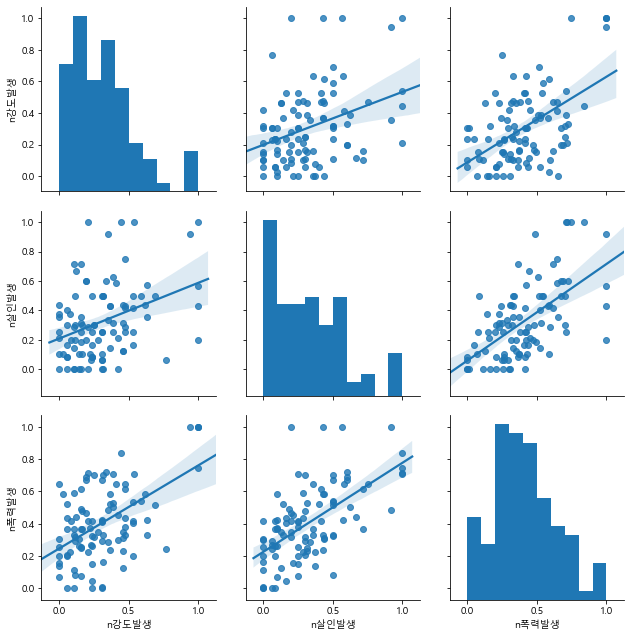

```python
sns.pairplot(n_dataseoul,vars=['n강도발생','n살인발생','n폭력발생'],
            kind='reg',size=3)
plt.show()
```

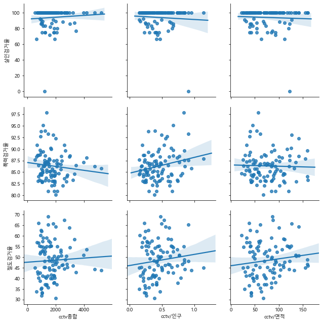

```python
sns.pairplot(n_dataseoul,
            x_vars=['cctv총합','cctv/인구','cctv/면적'],
            y_vars=['살인검거율','폭력검거율','절도검거율'],
            kind='reg',size=3)
plt.show()
```

- 살인검거율과 cctv자료들의 상관관계는 거의 없어보임
- 인구수 대비 cctv비율이 그나마 약한 양의 상관관계를 보임
- 나머지 변수들은 심지어 음의 상관관계까지 보임

```python
# n_dataseoul.to_excel('n_dataseoul.xlsx')
```

```python
# n_dataseoul.to_csv('n_dataseoul.csv')
```

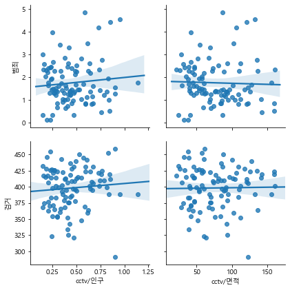

```python
sns.pairplot(n_dataseoul,
            x_vars=['cctv/인구','cctv/면적'],
            y_vars=['범죄','검거'],
            kind='reg',size=3)
plt.show()
```

### 범죄발생율과 CCTV사이의 상관관계 시각화

- 범죄 발생 전체 총합건수가 아닌 강도, 살인, 폭력건에 대해서만 상관분석 실시

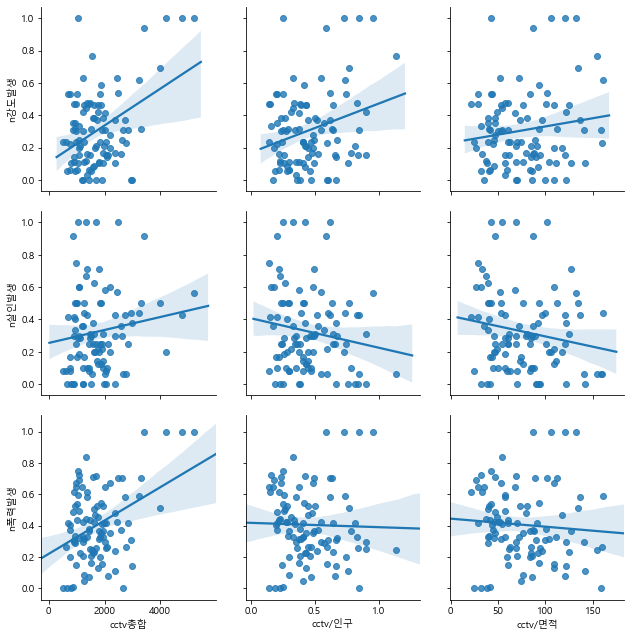

```python
sns.pairplot(n_dataseoul,
             y_vars=['n강도발생','n살인발생','n폭력발생'],
             x_vars=['cctv총합','cctv/인구','cctv/면적'],
            kind='reg',size=3)
plt.show()
```

- cctv총합 갯수는 전부 양의 상관관계
- 인구,면적대비 cctv는 강도발생에선 양의 상관관계, 나머지는 아주 약한 음의 상관관계를 보임
- 점들의 전체적 분포를 보면 크게 상관관계가 있어보이지 않음